# Background on state-dependent diversification rate estimation

An introduction to inference using state-dependent speciation and extinction (SSE) branching processes

## Introduction | introduction

This is a general introduction to character state-dependent branching process models, particularly as they are implemented in RevBayes. Frequently referred to as state-dependent speciation and extinction (SSE) models, these models are a birth-death process where the diversification rates are dependent on the state of an evolving character. The original model of this type considered a binary character (a trait with two discrete state values; called BiSSE, (Maddison, Midford, and Otto 2007). Several variants have also been developed for other types of traits (FitzJohn 2010, @Goldberg2011, @Goldberg2012, @MagnusonFord2012 @FitzJohn2012, @Beaulieu2016, @Freyman2018).

#Background: The BiSSE Model

The binary state speciation and extinction model (BiSSE) [Maddison, Midford, and Otto (2007) was introduced because of two problems identified by (Maddison 2006). First, inferences about character state transitions based on simple transition models [like (Pagel 1999) can be thrown off if the character affects rates of speciation or extinction. Second, inferences about whether a character affects lineage diversification based on sister clade comparisons (Mitter, Farrell, and Wiegemann 1988) can be thrown off if the transition rates are asymmetric. BiSSE and related models are now mostly used to assess if the states of a character are associated with different rates of speciation or extinction.

RevBayes implements the extension of BiSSE to any number of discrete states–*i.e.*, the MuSSE model in [diversitree](http://www.zoology.ubc.ca/prog/diversitree/); (FitzJohn 2012). We will first describe the general theory about the model.

# The theory behind state-dependent diversification models

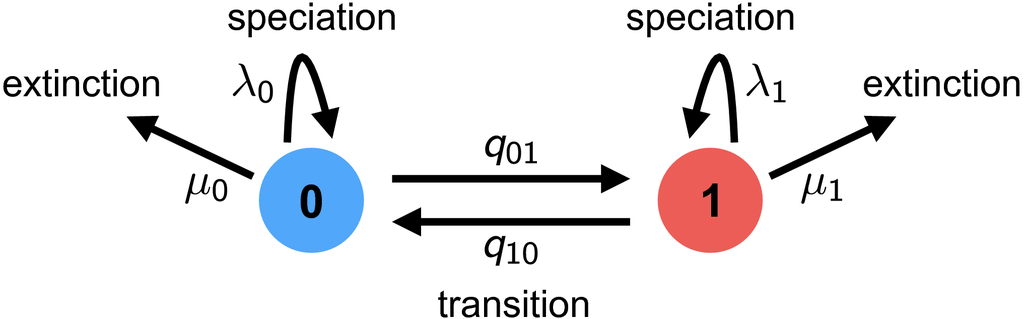

{% figcaption] A schematic overview of the BiSSE model. Each lineage has a binary trait associated with it, so it is either in state 0 (blue) or state 1 (red). When a lineage is in state 0, it can either (a) speciate with rate $\lambda_0$ which results into two descendant lineage both being in state 0; (b) go extinct with rate $\mu_0$; or (c) transition to state 1 with rate $q_{01}$. The same types of events are possible when a lineage is in state 1 but with rates $\lambda_1$, $\mu_1$, and $q_{10}$, respectively. {% endfigcaption] {% endfigure]

## General approach

The BiSSE model assumes two discrete states (*i.e.,* a binary character), and that the state of each extant species is known (*i.e.,* the discrete-valued character is observed). The general approach adopted by BiSSE and related models is to derive a set of ordinary differential equations (ODEs) that describe how the probability of observing a descendant clade changes along a branch in the observed phylogeny. Each equation in this set describes how the probability of observing a clade changes through time if it is in a particular state over that time period; collectively, these equations are called $\frac{\mathrm{d}D_{N,i}(t)}{\mathrm{d}t}$, where $i$ is the state of a lineage at time $t$ and $N$ is the clade descended from that lineage.

Computing the likelihood proceeds by establishing an initial value problem. We initialize the procedure by observing the character states of some lineages, generally the tip states. Then starting from those probabilities (*e.g.,* species X has state 0 with probability 1 at the present), we describe how those probabilities change over time (described by the ODEs), working our way back until we have computed the probabilities of observing that collection of lineages at some earlier time (*e.g.,* the root).

As we integrate from the tips to the root, we need to deal with branches coming together at nodes. Assuming that the parent and daughter lineages have the same state, we multiply together the probabilities that the daughters are state $i$ and the instantaneous speciation rate $\lambda_i$ to get the initial value for the ancestral branch subtending that node.

Proceeding in this way down the tree results in a set of $k$ probabilities at the root; these $k$ probabilities represent the probability of observing the phylogeny conditional on the root being in each of the states (*i.e.,* the $i^\text{th}$ conditional probability is the probability of observing the tree given that the root is in state $i$). The overall likelihood of the tree is a weighted average of the $k$ probabilities at the root, where the weighting scheme represents the assumed probability that the root was in each of the $k$ states.

As with all birth-death process models, special care must be taken to account for the possibility of extinction. Specifically, the above ODEs must accommodate lineages that may arise along each branch in the tree that subsequently go extinct before the present (and so are unobserved). This requires a second set of $k$ ODEs, $\frac{ \mathrm{d}E_{i}(t)}{\mathrm{d}t}$, which define how the probability of eventual extinction from state $i$ changes over time. These ODEs must be solved to compute the differential equations $\frac{ \mathrm{d}D_{N,i}(t)}{\mathrm{d}t}$. We will derive both sets of equations in the following sections.

## Derivation for the binary state birth-death process]

The derivation here follows the original description in {% citet Maddison2007]. Consider a (time-independent) birth-death process with two possible states (a binary character), with diversification rates
$$\{\lambda_0, \mu_0\}$$
and
$$\{\lambda_1, \mu_1\}$$
.

#### **Clade probabilities, $D_{N, i}$**

We define $D_{N,0}(t)$ as the probability of observing lineage $N$ descending from a particular branch at time $t$, given that the lineage at that time is in state 0. To compute the probability of observing the lineage at some earlier time point, $D_{N,0}(t + \Delta t)$, we enumerate all possible events that could occur within the interval $\Delta t$. Assuming that $\Delta t$ is small—so that the probability of more than one event occurring in the interval is negligible—there are four possible scenarios within the time interval ({% ref bisse_events]):

1. nothing happens;
2. a transition occurs, so the state changes $0 \rightarrow 1$;
3. a speciation event occurs, and the right descendant subsequently goes extinct before the present, or;
4. a speciation event occurs and the left descendant subsequently goes extinct before the present.

We are describing events within a branch of the tree (not at a node), so for (3) and (4), we require that one of the descendant lineages go extinct before the present because we do not observe a node in the tree between $t$ and $t + \Delta t$.

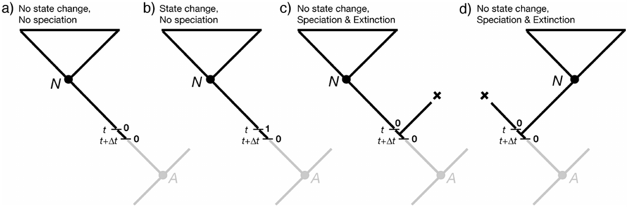

{% figcaption] Possible events along a branch in the BiSSE model, used for deriving $D_{N,0}(t + \Delta t)$. This is Figure 2 in {% citet Maddison2007]. {% endfigcaption] {% endfigure]

We can thus compute $D_{N,0}(t + \Delta t)$ as:

$$\begin{aligned}
D_{N,0}(t + \Delta t) = & \;(1 - \mu_0 \Delta t) \times & \text{in all cases, no extinction of the observed lineage} \\
& \;[ (1 - q_{01} \Delta t)(1 - \lambda_0 \Delta t) D_{N,0}(t) & \text{case (1) nothing happens} \\
& \; + (q_{01} \Delta t) (1 - \lambda_0 \Delta t) D_{N,1}(t) & \text{case (2) state change but no speciation} \\
& \; + (1 - q_{01} \Delta t) (\lambda_0 \Delta t) E_0(t) D_{N,0}(t) & \text{case (3) no state change, speciation, extinction} \\
& \; + (1 - q_{01} \Delta t) (\lambda_0 \Delta t) E_0(t) D_{N,0}(t)] & \text{case (4) no state change, speciation, extinction}
\end{aligned}$$

A matching equation can be written down for $D_{N,1}(t+\Delta t)$.

To convert these difference equations into differential equations, we take the limit $\Delta t \rightarrow 0$. With the notation that $i$ can be either state 0 or state 1, and $j$ is the other state, this yields:

$$\frac{\mathrm{d}D_{N,i}(t)}{\mathrm{d}t} = - \left(\lambda_i + \mu_i + q_{ij} \right) D_{N,i}(t) + q_{ij} D_{N,j}(t) + 2 \lambda_i E_i(t) D_{N,i}(t)
\tag{1}\label{eq:one}$$

### Extinction probabilities, $E_i$

To solve the above equations for $D_{N, i}$, we see that we need the extinction probabilities. Define $E_0(t)$ as the probability that a lineage in state 0 at time $t$ goes extinct before the present. To determine the extinction probability at an earlier point, $E_0(t+\Delta t)$, we can again enumerate all the possible events in the interval $\Delta t$ ({% ref BiSSE_Events_E]):

1. the lineage goes extinct within the interval;
2. the lineage neither goes extinct nor speciates, resulting in a single lineage that must eventually go extinct before the present;
3. the lineage neither goes extinct nor speciates, but there is a state change, resulting in a single lineage that must go extinct before the present, or;
4. the lineage speciates in the interval, resulting in *two* lineages that must eventually go extinct before the present.

$$\begin{aligned}
E_0(t + \Delta t) = &\; \mu_0\Delta t +
& \text{case (1) extinction in the interval} \\
& (1 - \mu_0\Delta t) \times & \text{no extinction in the interval and \dots} \\
& \;[(1-q_{01}\Delta t)(1-\lambda_0 \Delta t) E_0(t) & \text{case (2) nothing happens, but subsequent extinction} \\
& \;+ (q_{01}\Delta t) (1-\lambda_0 \Delta t) E_1(t) & \text{case (3) state change and subsequent extinction} \\
& \;+ (1 - q_{01} \Delta t) (\lambda_0 \Delta t) E_0(t)^2] & \text{case (4) speciation and subsequent extinctions}
\end{aligned}$$

Again, a matching equation for $E_1(t+\Delta t)$ can be written down.

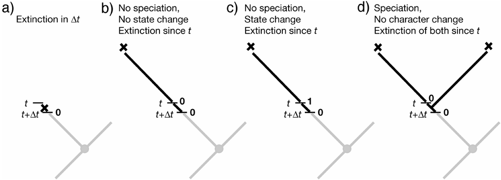

{% figcaption] Possible events along a branch in the BiSSE model, used for deriving $E_0(t + \Delta t)$. This is Figure 3 in {% citet Maddison2007]. {% endfigcaption] {% endfigure]

To convert these difference equations into differential equations, we again take the limit $\Delta t \rightarrow 0$:

$$\frac{\mathrm{d}E_i(t)}{\mathrm{d}t} = \mu_i - \left(\lambda_i + \mu_i + q_{ij} \right)E_i(t) + q_{ij} E_j(t) + \lambda_i E_i(t)^2
\tag{2}\label{eq:two}$$

### At nodes

$$D_{A, i}(t_A) = D_{N, i}(t_A) D_{M, i}(t_A) \lambda_i
\tag{3}\label{eq:three}$$

### At the root

$$\text{Likelihood(tree, tip states | model)} = \sum_i D_{R, i} \, p_{R, i}$$

What probability weighting, $p_{R, i}$ should be used for the possible root states? Sometimes a fixed approach is used, assuming that the prior root state probabilities are either all equal, or are the same as the observed tip state frequencies, or are the equilibrium state frequencies under the model parameters. These assumptions do not have a real basis, however (unless there is some external data that supports them), and they can cause trouble (Goldberg and Igić 2008). An alternative is to use the BiSSE probabilities themselves to determine the root state weightings, essentially adjusting the weightings to be most consistent with the data and BiSSE parameters (FitzJohn, Maddison, and Otto 2009). Perhaps better is to treat the weightings as unknown parameters to be estimated. These estimates are usually quite uncertain, but in a Bayesian framework, one can treat the $p_{R, i}$ as nuisance parameters and integrate over them.

### BiSSE model parameters and their interpretation

| Parameter | Interpretation |
| --- | --- |
| $\Psi$ | Phylogenetic tree with divergence times |
| $T$ | Root age |
| $q_{01}$ | Rate of transitions from 0 to 1 |
| $q_{10}$ | Rate of transitions from 1 to 0 |
| $\lambda_0$ | Speciation rate for state 0 |
| $\mu_0$ | Extinction rate for state 0 |
| $\lambda_1$ | Speciation rate for state 1 |
| $\mu_1$ | Extinction rate for state 1 |

## Equations for the multi-state birth-death process]

The entire derivation above can easily be expanded to accommodate an arbitrary number of states (FitzJohn 2012). The only extra piece is summing over all the possible state transitions. The resulting differential equations within the branches are:

$$\begin{aligned}
\frac{\mathrm{d}D_{N,i}(t)}{\mathrm{d}t} &= - \left(\lambda_i + \mu_i + \sum\limits_{j \neq i}^k q_{ij} \right)D_{N,i}(t) + \sum\limits_{j \neq i}^k q_{ij} D_{N,j}(t) + 2\lambda_iE_i(t)D_{N,i}(t) \\
\frac{\mathrm{d}E_i(t)}{\mathrm{d}t} &= \mu_i - \left(\lambda_i + \mu_i + \sum\limits_{j \neq i}^k q_{ij} \right)E_i(t) + \sum\limits_{j \neq i}^k q_{ij} E_j(t) + \lambda_i E_i(t)^2
\end{aligned}$$

Beaulieu, Jeremy M, and Brian C O’Meara. 2016. “Detecting hidden diversification shifts in models of trait-dependent speciation and extinction.” *Systematic Biology* 65 (4): 583–601. https://doi.org/10.1093/sysbio/syw022.

FitzJohn, R. G., W. P. Maddison, and S. P. Otto. 2009. “Estimating trait-dependent speciation and extinction rates from incompletely resolved phylogenies.” *Systematic Biology* 58 (6): 595–611. https://doi.org/10.1093/sysbio/syp067.

FitzJohn, Richard G. 2010. “Quantitative Traits and Diversification.” *Systematic Biology* 59 (6): 619–33. https://doi.org/10.1093/sysbio/syq053.

———. 2012. “Diversitree: Comparative Phylogenetic Analyses of Diversification in R.” *Methods in Ecology and Evolution* 3 (6): 1084–92. https://doi.org/10.1111/j.2041-210X.2012.00234.x.

Freyman, William A., and Sebastian Höhna. 2018. “Cladogenetic and anagenetic models of chromosome number evolution: a Bayesian model averaging approach.” *Systematic Biology* 67 (2): 1995–1215.

Goldberg, Emma E., and Boris Igić. 2008. “On Phylogenetic Tests of Irreversible Evolution.” *Evolution* 62: 2727–41. https://doi.org/10.1111/j.1558-5646.2008.00505.x.

———. 2012. “Tempo and Mode in Plant Breeding System Evolution.” *Evolution* 66: 3701–9. https://doi.org/10.1111/j.1558-5646.2012.01730.x.

Goldberg, Emma E, Lesley T Lancaster, and Richard H Ree. 2011. “Phylogenetic Inference of Reciprocal Effects Between Geographic Range Evolution and Diversification.” *Systematic Biology* 60 (4): 451–65. https://doi.org/10.1093/sysbio/syr046.

Maddison, Wayne P. 2006. “Confounding Asymmetries in Evolutionary Diversification and Character Change.” *Evolution* 60: 1743–6. https://doi.org/10.1111/j.0014-3820.2006.tb00517.x.

Maddison, W. P., P. E. Midford, and S. P. Otto. 2007. “Estimating a binary character’s effect on speciation and extinction.” *Systematic Biology* 56 (5): 701. https://doi.org/10.1080/10635150701607033.

Magnuson-Ford, Karen, and Sarah P Otto. 2012. “Linking the Investigations of Character Evolution and Species Diversification.” *The American Naturalist* 180 (2): 225–45. https://doi.org/10.1086/666649.

Mitter, C., B. Farrell, and B. Wiegemann. 1988. “The Phylogenetic Study of Adaptive Zones: Has Phytophagy Promoted Insect Diversification?” *The American Naturalist* 132: 107–28. https://doi.org/10.1086/284840.

Pagel, Mark. 1999. “The Maximum Likelihood Approach to Reconstructing Ancestral Character States of Discrete Characters on Phylogenies.” *Systematic Biology* 48: 612–22. https://doi.org/10.1080/106351599260184.